# Transfer Learning

En este notebook resolveremos un problema real usando redes pre-entrenadas y transfer learning.

## Patrones geométricos de Kunisch

En el año 1998, Norbert Kunisch (un reconocido arqueólogo clásico alemán) publicó su libro "Ornamente Geometrischer Vasen", en donde clasificó diferentes patrones geométricos de vasijas griegas que se encuentran en diferentes museos de Europa. Su trabajo fue muy importante para determinar tiempos y ubicaciones de muchos objetos esparcidos por todo el continente.

Su libro es un compendio de los diferentes patrones geométricos presentes en vasijas y las anotaciones textuales de los patrones en diferentes idiomas.

[figure not shown]

# El problema

En el museo de arqueología Schloss Eggenberg quieren realizar un análisis automático de patrones en vasijas usando el compendio de Kunisch. Para esto nosotros realizamos primero un trabajo de escaneo del libro entero y de OCR para extraer tanto los patrones como las anotaciones textuales.

Como resultado tenemos 348 patrones, clasificados en seis clases:

- Ornamentos circulares
- Ornamentos triangulares
- Ornamenros rectangulares
- Pictografías
- Trazos y líneas
- Romboidales

Nuestro primer objetivo es encontrar una forma de lograr una alta eficacia de clasificación de estos patrones. Sin embargo, al tener muy poca data, trataremos de resolverlo con la técnica dle transfer learning.

```python
#!rm -r dataset/
```

```python
# Descargamos la data
!wget http://www.ivan-sipiran.com/downloads/data_patterns2.zip
!unzip data_patterns2.zip
```

```
--2023-10-28 02:03:36--  http://www.ivan-sipiran.com/downloads/data_patterns2.zip
Resolving www.ivan-sipiran.com (www.ivan-sipiran.com)... 66.96.149.31
Connecting to www.ivan-sipiran.com (www.ivan-sipiran.com)|66.96.149.31|:80... connected.
HTTP request sent, awaiting response... 200 OK
Length: 28575047 (27M) [application/zip]
Saving to: ‘data_patterns2.zip.1’

data_patterns2.zip. 100%[===================>]  27.25M  50.7MB/s    in 0.5s

2023-10-28 02:03:36 (50.7 MB/s) - ‘data_patterns2.zip.1’ saved [28575047/28575047]

Archive:  data_patterns2.zip
replace data/class_labels.csv? [y]es, [n]o, [A]ll, [N]one, [r]ename:
```

# La Solución

Primero creamos nuestras tres colecciones de datos: train, val y test. Los datos de train serán usados para entrenar el modelo, los datos de validación serán usados para probar el modelo durante entrenamiento, y los datos de test serán usados para evaluar el performance final del modelo.

Hacemos un poco de data engineering para crear nuestras colecciones.

- Datos de train: 70%
- Datos de val: 10%
- Datos de test: 20%

La partición se hace dentro de cada clase para asegurar representatividad en cada clase.

```python
import pandas as pd
import math
import random
import os
import shutil
import matplotlib.pyplot as plt
import numpy as np

import torch
import torch.nn as nn
import torch.nn.functional as F
import torchvision
import numpy as np
from torchvision import datasets, models, transforms
import time
import os
import copy

SEED = 1234567890

random.seed(SEED)
np.random.seed(SEED)
torch.manual_seed(SEED)
torch.cuda.manual_seed(SEED)
torch.backends.cudnn.deterministic = True
torch.backends.cudnn.benchmark = False

#Leemos la metadata del dataset desde el archivo CSV

df = pd.read_csv('data/class_labels.csv', header=None)
classes = df[1].unique()
classesFinal = [cl.replace(' ', '_') for cl in classes]
print(classesFinal)

#Creamos folders para almacenar la data. NOTA: trata de ejecutar esta celda solo una vez, ya que
# crea los folders y ese paso solo se ejecuta una vez
try:
  os.mkdir('dataset')
except OSError:
  print ("No se pudo crear folder dataset")
else:
  print ("Se creó folder dataset")

try:
  os.mkdir('dataset/train')
except OSError:
  print ("No se pudo crear folder dataset")
else:
  print ("Se creó folder dataset")

try:
  os.mkdir('dataset/test')
except OSError:
  print ("No se pudo crear folder dataset")
else:
  print ("Se creó folder dataset")

try:
  os.mkdir('dataset/val')
except OSError:
  print ("No se pudo crear folder dataset")
else:
  print ("Se creó folder dataset")

for cl in classesFinal:
  try:
    os.mkdir(os.path.join('dataset', "train", cl))
  except OSError:
    print (f"No se pudo crear folder train {cl}")
  else:
    print (f"Se creó folder train {cl}")

  try:
    os.mkdir(os.path.join('dataset', "test", cl))
  except OSError:
    print (f"No se pudo crear folder test {cl}")
  else:
    print (f"Se creó folder test {cl}")

  try:
    os.mkdir(os.path.join('dataset', "val", cl))
  except OSError:
    print (f"No se pudo crear folder val {cl}")
  else:
    print (f"Se creó folder val {cl}")
```

```
['circular_ornaments', 'triangular_ornaments', 'rectangular_ornaments', 'pictographics', 'lozenge', 'strokes_and_lines']
No se pudo crear folder dataset
No se pudo crear folder dataset
No se pudo crear folder dataset
No se pudo crear folder dataset
No se pudo crear folder train circular_ornaments
No se pudo crear folder test circular_ornaments
No se pudo crear folder val circular_ornaments
No se pudo crear folder train triangular_ornaments
No se pudo crear folder test triangular_ornaments
No se pudo crear folder val triangular_ornaments
No se pudo crear folder train rectangular_ornaments
No se pudo crear folder test rectangular_ornaments
No se pudo crear folder val rectangular_ornaments
No se pudo crear folder train pictographics
No se pudo crear folder test pictographics
No se pudo crear folder val pictographics
No se pudo crear folder train lozenge
No se pudo crear folder test lozenge
No se pudo crear folder val lozenge
No se pudo crear folder train strokes_and_lines
No se pudo crear folder test strokes_and_lines
No se pudo crear folder val strokes_and_lines
```

```python
#Hacemos el pre-procesamiento de los datos, cada imagen va a parar a su respectivo folder
dataset = dict()
#Acá se crea un diccionario con todas las clases y la imagenes que corresponden a esa clase.
for index, cl in enumerate(classes):
    grouped_data = df.groupby(1).get_group(cl)[0].tolist()
    dataset[classesFinal[index]] = grouped_data
#Se cuentan cuantos elementos hay por cada clase
for k,v in dataset.items():
    print(f'Class: {k}, Length: {len(v)}')

for k,v in dataset.items():
    #Primero se calcula la cantidad de imagenes para train, val y test
    valNumber = math.ceil(0.1 * len(v))
    testNumber = math.ceil(0.2 * len(v))
    trainNumber = len(v) - valNumber - testNumber

    #Hace un random de v, es decir, de la lista de imagenes de la clase k
    random.shuffle(v)

    #Separa en elementos para el train, val y test.
    elemTrain = v[:trainNumber]
    elemVal = v[trainNumber:trainNumber+valNumber]
    elemTest = v[trainNumber+valNumber:]

    assert (valNumber + testNumber + trainNumber) == len(v)

    pathTrain = './dataset/train/'
    pathSource = './data/patrones/'

    #Copiar archivos de train
    for elem in elemTrain: # Para cada k (clase), copia todos los elementos selecciondados de la clase k para train y los copia en una carpeta nueva.
        shutil.copy(os.path.join(pathSource,elem,elem+'_pattern.png'), os.path.join(pathTrain, k))

    #Crea los directorios para test y val y hace lo mismo que antes.
    pathTest = './dataset/test/'
    pathSource = './data/patrones/'

    #Copiar archivos de test
    for elem in elemTest:
        shutil.copy(os.path.join(pathSource,elem,elem+'_pattern.png'), os.path.join(pathTest, k))

    pathVal = './dataset/val/'
    pathSource = './data/patrones/'

    #Copiar archivos de train
    for elem in elemVal:
        shutil.copy(os.path.join(pathSource,elem,elem+'_pattern.png'), os.path.join(pathVal, k))
```

```
Class: circular_ornaments, Length: 72
Class: triangular_ornaments, Length: 81
Class: rectangular_ornaments, Length: 87
Class: pictographics, Length: 26
Class: lozenge, Length: 46
Class: strokes_and_lines, Length: 36
```

# Creación de Datasets

Se crean los datasets y dataloaders de Pytorch, que usarás para tu tarea.

```python
pathDataset = 'dataset/'
#Se procede a hacer Data Augmentation, haciendo rotaciones principalmente a la data y flips. Esto se hizo dado que las figuras a estudiar podían presentar simetría en muchos casos.

train_dataset1 = torchvision.datasets.ImageFolder(pathDataset + 'train',
                                                    transform = transforms.Compose([
                                                        transforms.RandomVerticalFlip(),
                                                        transforms.CenterCrop(224),
                                                                    transforms.ToTensor(),
                                                                    transforms.Normalize(mean=[0.485, 0.456, 0.406],
                                                                                        std = [0.229, 0.224, 0.225])]))
train_dataset2 = torchvision.datasets.ImageFolder(pathDataset + 'train',
                                                    transform = transforms.Compose([
                                                        transforms.RandomHorizontalFlip(),
                                                        transforms.CenterCrop(224),
                                                                    transforms.ToTensor(),
                                                                    transforms.Normalize(mean=[0.485, 0.456, 0.406],
                                                                                        std = [0.229, 0.224, 0.225])]))
train_dataset3 = torchvision.datasets.ImageFolder(pathDataset + 'train',
                                                    transform = transforms.Compose([
                                                        transforms.RandomRotation(degrees=360),
                                                        transforms.CenterCrop(224),
                                                                    transforms.ToTensor(),
                                                                    transforms.Normalize(mean=[0.485, 0.456, 0.406],
                                                                                        std = [0.229, 0.224, 0.225])]))
train_dataset4 = torchvision.datasets.ImageFolder(pathDataset + 'train',
                                                    transform = transforms.Compose([
                                                        transforms.RandomResizedCrop(224),
                                                        transforms.RandomRotation(degrees=360),
                                                                    transforms.ToTensor(),
                                                                    transforms.Normalize(mean=[0.485, 0.456, 0.406],
                                                                                        std = [0.229, 0.224, 0.225])]))

train_dataset6 = torchvision.datasets.ImageFolder(pathDataset + 'train',
                                                    transform = transforms.Compose([
                                                        transforms.RandomResizedCrop(224),
                                                                    transforms.ToTensor(),
                                                                    transforms.Normalize(mean=[0.485, 0.456, 0.406],
                                                                                        std = [0.229, 0.224, 0.225])]))




from torch.utils.data import ConcatDataset
#Se concatenan.
train_dataset = ConcatDataset([train_dataset1, train_dataset2, train_dataset3,
                              train_dataset4,train_dataset6])



val_dataset = torchvision.datasets.ImageFolder(pathDataset + 'val',
                                                    transform = transforms.Compose([ transforms.Resize(256),
                                                                    transforms.CenterCrop(224),
                                                                    transforms.ToTensor(),
                                                                    transforms.Normalize(mean=[0.485, 0.456, 0.406],
                                                                                        std = [0.229, 0.224, 0.225])]))

test_dataset = torchvision.datasets.ImageFolder(pathDataset + 'test',
                                                    transform = transforms.Compose([ transforms.Resize(224),
                                                                    transforms.ToTensor(),
                                                                    transforms.Normalize(mean=[0.485, 0.456, 0.406],
                                                                                        std = [0.229, 0.224, 0.225])]))
#Se define un batch size grande dado que se aumento bastante la data.
train_loader = torch.utils.data.DataLoader(train_dataset, batch_size=128,shuffle=True, num_workers=0, worker_init_fn=np.random.seed(SEED))
val_loader = torch.utils.data.DataLoader(val_dataset, batch_size=128, shuffle=True, num_workers=0, worker_init_fn=np.random.seed(SEED))
test_loader = torch.utils.data.DataLoader(test_dataset, batch_size=1, shuffle=True, num_workers=0, worker_init_fn=np.random.seed(SEED))
```

# Solución 1: Fine-tuning

Utiliza fine-tuning para el problema anterior y reporta el accuracy de test. Intenta obtener el accuracy de test más alto posible, sin que el modelo haga overfitting. Considera overfitting cuando la diferencia entre accuracy de train y accuracy de validación tengan una diferencia de más de 5%.

```python
device = ('cuda' if torch.cuda.is_available() else 'cpu')
print(device)



# Se utiliza función base del laboratorio 8, disponible en github.
def train_model(name, model, criterio, optimizer, scheduler, num_epochs = 25):
  since = time.time()

  best_model_wts = copy.deepcopy(model.state_dict())
  best_acc = 0.0
  train_losses = []
  val_losses = []
  train_accs = []
  val_accs = []
  print(f'Comenzando el entrenamiento del modelo {name}...')

  for epoch in range(num_epochs):
    print('Epoch {}/{}'.format(epoch+1, num_epochs))
    print('-' * 10)

    #Train model
    # scheduler.step()
    model.train()

    running_loss = 0.0
    running_corrects = 0.0

    for inputs, labels in train_loader:
        inputs = inputs.to(device)
        labels = labels.to(device)

        optimizer.zero_grad()

        outputs = model(inputs)
        _, preds = torch.max(outputs, 1)
        loss = criterion(outputs, labels)

        loss.backward()
        optimizer.step()
        scheduler.step()

        running_loss += loss.item() * inputs.size(0)
        running_corrects += torch.sum(preds == labels.data)

    epoch_loss_train = running_loss /len(train_dataset)
    epoch_acc_train = running_corrects.double() / len(train_dataset)
    train_losses.append(epoch_loss_train)
    train_accs.append(epoch_acc_train)

    print('Train Loss: {:.4f} Acc: {:.4f}'.format(epoch_loss_train, epoch_acc_train))

    #Validation
    model.eval()
    running_loss = 0.0
    running_corrects = 0.0

    for inputs, labels in val_loader:
      inputs = inputs.to(device)
      labels = labels.to(device)

      with torch.set_grad_enabled(False):
        outputs = model(inputs)
        _, preds = torch.max(outputs, 1)
        loss = criterion(outputs, labels)

      running_loss += loss.item() * inputs.size(0)
      running_corrects += torch.sum(preds == labels.data)

    epoch_loss_val = running_loss /len(val_dataset)
    epoch_acc_val = running_corrects.double() / len(val_dataset)
    val_losses.append(epoch_loss_val)
    val_accs.append(epoch_acc_val)

    print('Val Loss: {:.4f} Acc: {:.4f}'.format(epoch_loss_val, epoch_acc_val))

    if abs(epoch_acc_val-epoch_acc_train) <= 0.05:
      # print(abs(epoch_acc_val-epoch_acc_train))
      if epoch_acc_val > best_acc:
          best_acc = epoch_acc_val
          best_model_wts = copy.deepcopy(model.state_dict())

  time_elapsed = time.time() - since
  print('Training complete in {:.0f}m {:.0f}s'.format(time_elapsed//60, time_elapsed % 60))
  print('Best val accucary: {:.4f}'.format(best_acc))

  model.load_state_dict(best_model_wts)
  return [model, train_losses, val_losses, train_accs, val_accs, name, num_epochs]
```

```
cuda
```

```python
import torchsummary as ts
# ts.summary(Modelo_finetuning.to(device), input_size=(3,224,224))
```

```python
class Modelo_custom(nn.Module):
    def __init__(self, modelo_base, n_clases, dropout_prob = 0.5, freeze_model = False):
        super(Modelo_custom, self).__init__()
        self.modelo_base = modelo_base

        if freeze_model:
            for param in self.modelo_base.parameters():
                param.requires_grad = False

        self.fc1 = nn.Linear(modelo_base.fc.out_features, 100)
        self.relu1 = nn.ReLU()
        self.dropout1 = nn.Dropout(p=dropout_prob)
        self.fc2 = nn.Linear(100, n_clases)
        # self.relu2 = nn.ReLU()
        # self.dropout2 = nn.Dropout(p=dropout_prob)
        # self.fc3 = nn.Linear(200, n_clases)

    def forward(self, x):
        x = self.modelo_base(x)
        x = self.fc1(x)
        x = self.relu1(x)
        x = self.dropout1(x)
        x = self.fc2(x)
        # x = self.relu2(x)
        # x = self.dropout2(x)
        # x = self.fc3(x)
        return x
```

```python
def graficar(model_list):
    model = model_list[0]
    train_losses = model_list[1]
    val_losses = model_list[2]
    train_accs = model_list[3]
    train_accs = [tensor.item() for tensor in train_accs]
    val_accs = model_list[4]
    val_accs = [tensor.item() for tensor in val_accs]
    name = model_list[5]

    best_val_acc = max(val_accs)
    best_val_acc_index = val_accs.index(best_val_acc)

    n_epoch = model_list[6]
    epoch = range(1,len(train_losses)+1)
    fig, axes = plt.subplots(nrows=1, ncols=2, figsize=(12, 5))  # Dos gráficos en una fila
    axes[0].plot(epoch, train_losses, label='Train Losses', color='b')
    axes[0].plot(epoch, val_losses, label='Val Losses', color='r')
    axes[0].set_title('Función de Pérdidas')
    axes[0].set_xlabel('Épocas')
    axes[0].set_ylabel('Loss')
    axes[0].legend()
    axes[1].plot(epoch, train_accs, label='Train_Acc', color='b')
    axes[1].plot(epoch, val_accs, label='Val_Acc', color='r')
    axes[1].axhline(y=best_val_acc, color='r', linestyle='--', label=f'Best Validation Acc: {best_val_acc:.2f}')
    axes[1].text(len(val_accs) - 1, best_val_acc, f'{best_val_acc:.2f}', ha='right', va='bottom')

    axes[1].set_title('Accuracy')
    axes[1].set_xlabel('Época')
    axes[1].set_ylabel('Accuracy')
    axes[1].legend()
    plt.suptitle(f'Entrenamiento {name}, {n_epoch} epocas.')
    plt.tight_layout()
    plt.show()
```

```python
import torch
import seaborn as sns
from sklearn.metrics import confusion_matrix
from sklearn.utils.multiclass import unique_labels
from sklearn.metrics import classification_report


def evaluate_model(model, test_loader, criterion):
    model.eval()

    running_corrects = 0
    total_samples = 0
    preds = []
    labels = []

    with torch.no_grad():
        for input, label in test_loader:
            input = input.to(device)
            label = label.to(device)

            outputs = model(input)
            _, pred = torch.max(outputs, 1)
            running_corrects += torch.sum(pred == label.data)
            total_samples += label.size(0)
            preds.extend(pred.cpu().numpy())
            labels.extend(label.cpu().numpy())

    accuracy = running_corrects.double() / total_samples

    cm = confusion_matrix(labels, preds, normalize='true')

    # Only use the labels that appear in the data
    # classes_cm = unique_labels(labels, preds)
    print(f'Accuracy en el conjunto de prueba: {accuracy:.4f}')

    df = pd.DataFrame(cm, index=classes, columns=classes)

    g = sns.heatmap(df, annot=True, cmap="Blues")
    g.set_yticklabels(g.get_yticklabels(), rotation=0)

    plt.title('Confusion matrix \n')
    plt.xlabel('Predicted label')
    plt.ylabel('True label')
    plt.autoscale()
    plt.show()
    plt.close()
    # print(classification_report(labels, preds))

    return accuracy
```

```
Comenzando el entrenamiento del modelo FineTunningResNet18...
----------
Train Loss: 1.3465 Acc: 0.4787
Val Loss: 0.6840 Acc: 0.7746
----------
Train Loss: 0.7828 Acc: 0.7124
Val Loss: 0.3808 Acc: 0.9155
----------
Train Loss: 0.5695 Acc: 0.7968
Val Loss: 0.3377 Acc: 0.9155
----------
Train Loss: 0.4590 Acc: 0.8470
Val Loss: 0.3368 Acc: 0.9296
----------
Train Loss: 0.3955 Acc: 0.8756
Val Loss: 0.3035 Acc: 0.9577
----------
Train Loss: 0.3367 Acc: 0.8902
Val Loss: 0.2915 Acc: 0.9577
----------
Train Loss: 0.3190 Acc: 0.8895
Val Loss: 0.2824 Acc: 0.9437
----------
Train Loss: 0.3067 Acc: 0.8940
Val Loss: 0.3049 Acc: 0.9437
----------
Train Loss: 0.2804 Acc: 0.9029
Val Loss: 0.2943 Acc: 0.9437
----------
Train Loss: 0.2617 Acc: 0.9079
Val Loss: 0.2910 Acc: 0.9577
----------
Train Loss: 0.2692 Acc: 0.9098
Val Loss: 0.2833 Acc: 0.9577
----------
Train Loss: 0.2518 Acc: 0.9187
Val Loss: 0.2851 Acc: 0.9577
----------
Train Loss: 0.2695 Acc: 0.9130
Val Loss: 0.3013 Acc: 0.9577
----------
Train Loss: 0.2855 Acc: 0.9054
Val Loss: 0.2882 Acc: 0.9577
----------
Train Loss: 0.2711 Acc: 0.9124
Val Loss: 0.2889 Acc: 0.9577
Training complete in 2m 56s
Best val accucary: 0.9577
```

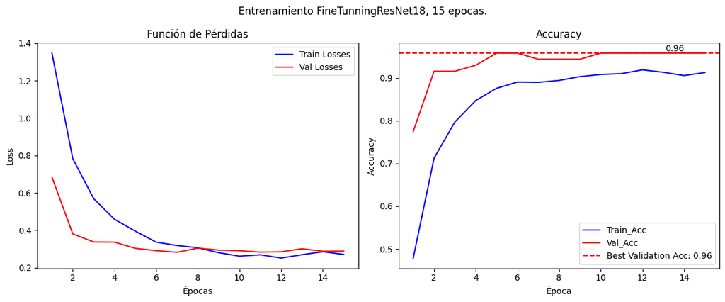

```
Accuracy en el conjunto de prueba: 0.9630
```

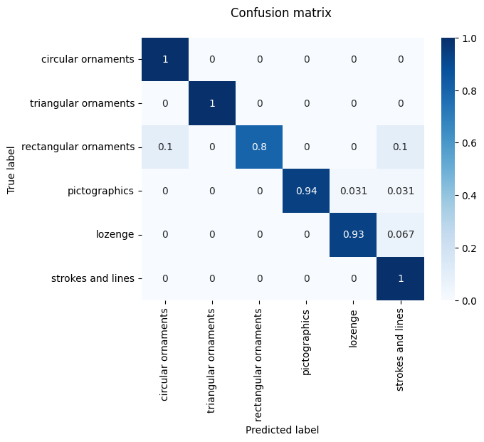

```python
#Fine tuning
import torch.optim as optim
model_ft = models.resnet18(weights='ResNet18_Weights.DEFAULT')
Modelo_finetuning = Modelo_custom(model_ft, n_clases=6)
Modelo_finetuning = Modelo_finetuning.to(device)
criterion = nn.CrossEntropyLoss()
optimizer = torch.optim.SGD(Modelo_finetuning.parameters(), lr=0.05, momentum=0.3)

# optimizer = optim.AdamW(Modelo_finetuning.parameters(), lr=0.001, weight_decay=1e-4)
exp_lr_scheduler = torch.optim.lr_scheduler.StepLR(optimizer, step_size=5, gamma=0.9)
model_ft_list = train_model('FineTunningResNet18',Modelo_finetuning, criterion, optimizer, exp_lr_scheduler, num_epochs=15)


graficar(model_ft_list)
test_accuracy = evaluate_model(model_ft_list[0], test_loader, criterion)
```

```python
#torch.save(model_ft_list[0], 'best_model_finetunnig.pth')
```

### Respuesta:

> El problema debe ser afrontado con Fine Tunning, dado que entrenar directamente con la data disponible no daría buenos resultados al tener tan pocos datos. Se utiliza la CNN pre-entrenada Resnet18 y se agregan capas posteriores para realizar la clasificación. Notar que la red CNN obtiene las características de las imagenes y mediante Fine Tunning, se re-ajustan los pesos de toda la nueva arquitectura.

> En un comienzo se probó con la red ResNet18 con la misma configuración de las capas fc, incluyendo la capa no lineal ReLu(). Dada la cantidad de la data disponible para entrenar fue necesario realizar data Augmentation al dataset de train. Esta consistió en realizar una serie de transformaciones a la data de train, como pueden ser rotaciones y flips. Después de mucha prueba de error se decidió dejar al arquitectura y la data de train como muestra el presente notebook.

> Los mejores resultados obtenidos muestran que en el conjunto de validación se obtiene un accuracy de un 96% y un 91% en el conjunto de entrenamiento. Al probar en el conjunto de test, se obtiene un accuracy de un 0.96. Estos resultados son muy buenos, mostrando que la arquitectura aprende y, más aún, logra generalizar.

> Agregar Dropout en clasificación fue clave para reducir el sobreajuste, por lo que se estima que fue una muy buena estrategia.

> Se evidencia que un problema como este requiere de prueba y error. Lo que más podría acelerar el proceso es contar con ayuda de un experto del tema a tratar, conocer más sobre el dataset y con esto hacer un buen pre-procesado de datos. Por ejemplo, después de observar un poco las imagenes se llegó a la conlusión que algunas se parecen mucho a otras rotadas, por lo que se aplicó esa transformación al conjunto de entrenamiento. Data Augmentation fue fundamental, dado que permitió agregar la variabilidad necesaria para aprender.

> La matriz de confusión muestra que el resultado general es excelente, practicamente clasifica bien todas las clases.

**Nota:** al no estar completamente seguro de si la semilla bastará para replicar, se adjunta el modelo.

# Solución 2: Freezing

Utiliza freezing para el problema anterior y reporta el accuracy de test. Intenta obtener el accuracy de test más alto posible, sin que el modelo haga overfitting. Considera overfitting ting cuando la diferencia entre accuracy de train y accuracy de validación tengan una diferencia de más de 5%.

```
Comenzando el entrenamiento del modelo FreezingTunningResNet18...
----------
Train Loss: 1.4424 Acc: 0.4514
Val Loss: 1.1125 Acc: 0.6338
----------
Train Loss: 1.0851 Acc: 0.5848
Val Loss: 0.9062 Acc: 0.6620
----------
Train Loss: 0.9721 Acc: 0.6406
Val Loss: 0.8331 Acc: 0.6901
----------
Train Loss: 0.8937 Acc: 0.6876
Val Loss: 0.7721 Acc: 0.7324
----------
Train Loss: 0.8689 Acc: 0.6730
Val Loss: 0.7100 Acc: 0.7746
----------
Train Loss: 0.8080 Acc: 0.7251
Val Loss: 0.7145 Acc: 0.8028
----------
Train Loss: 0.7640 Acc: 0.7219
Val Loss: 0.6775 Acc: 0.8028
----------
Train Loss: 0.7807 Acc: 0.7238
Val Loss: 0.6638 Acc: 0.8028
----------
Train Loss: 0.7630 Acc: 0.7168
Val Loss: 0.6594 Acc: 0.7887
----------
Train Loss: 0.7759 Acc: 0.7238
Val Loss: 0.6488 Acc: 0.7606
----------
Train Loss: 0.7616 Acc: 0.7257
Val Loss: 0.6567 Acc: 0.7606
----------
Train Loss: 0.6982 Acc: 0.7511
Val Loss: 0.6444 Acc: 0.7746
----------
Train Loss: 0.7348 Acc: 0.7422
Val Loss: 0.6374 Acc: 0.7746
```

[output cut: 38 more lines]

```
Val Loss: 0.6355 Acc: 0.7746
----------
Train Loss: 0.7269 Acc: 0.7283
Val Loss: 0.6283 Acc: 0.7746
----------
Train Loss: 0.7141 Acc: 0.7486
Val Loss: 0.6233 Acc: 0.7887
----------
Train Loss: 0.7259 Acc: 0.7429
Val Loss: 0.6387 Acc: 0.7746
----------
Train Loss: 0.7124 Acc: 0.7511
Val Loss: 0.6316 Acc: 0.7746
Training complete in 4m 24s
Best val accucary: 0.7887
```

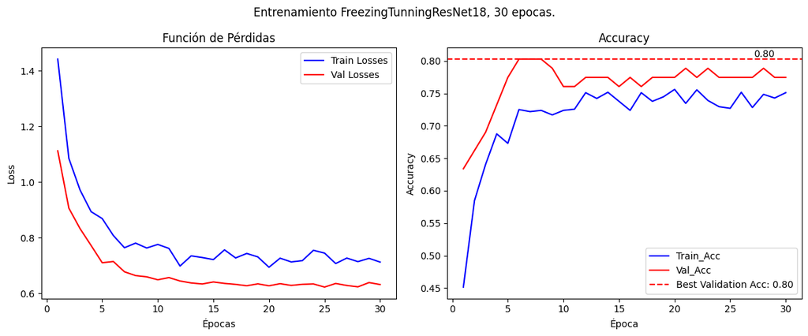

```
Accuracy en el conjunto de prueba: 0.8370
```

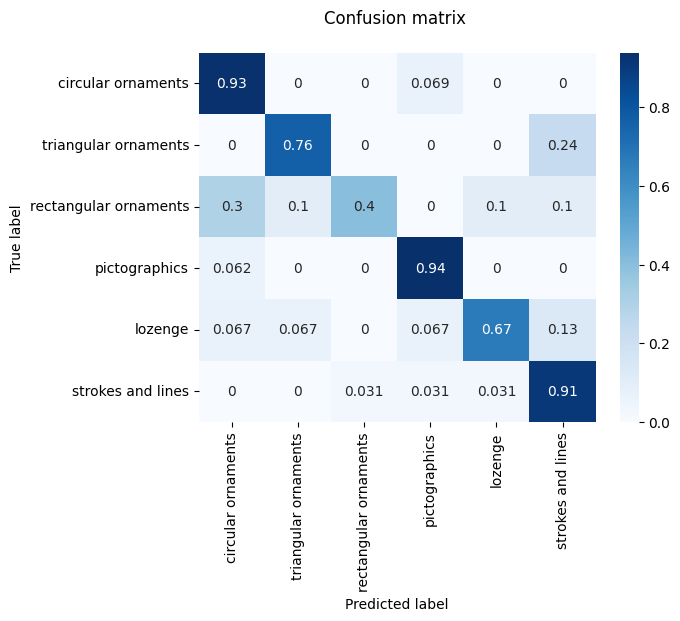

```
Accuracy en el conjunto de prueba: 0.8370
```

```python
#Freezing
import torch.optim as optim
model_freezing = models.resnet18(weights='ResNet18_Weights.DEFAULT')
Modelo_freezing = Modelo_custom(model_freezing, n_clases=6, freeze_model=True )
Modelo_freezing = Modelo_freezing.to(device)
criterion = nn.CrossEntropyLoss()
optimizer = torch.optim.SGD(Modelo_freezing.parameters(), lr=0.05, momentum=0.35)

exp_lr_scheduler = torch.optim.lr_scheduler.StepLR(optimizer, step_size=5, gamma=0.9)
model_freezing_list = train_model('FreezingTunningResNet18',Modelo_freezing, criterion, optimizer, exp_lr_scheduler, num_epochs=30)

graficar(model_freezing_list)
test_accuracy_freezing = evaluate_model(model_freezing_list[0], test_loader, criterion)
print(f'Accuracy en el conjunto de prueba: {test_accuracy_freezing:.4f}')
```

```python
#torch.save(model_freezing_list[0], 'best_model_freezing.pth')
```

### Respuesta:

> De lo anterior se evidencia la utilidad de aplicar freezing sobre la red pre-entrenada. Aquí se dejan los pesos de esta por defecto y se modifican los de la etapa de clasificación. Es un proceso mucho más rápido que el anterior dado que se realizan menos actualizaciones. Sin embargo, esto puede significar que no logre alcanzar ser más específico en lo que sabe la red o no.

> Los resultados obtenidos son peores que en el caso anterior, pero esto puede variar dependiendo de el problema al que se enfrenta. Es por esto que no se puede establecer que uno sea mejor que otro, se debe probar en cada caso.

> Se obtiene 75%, 79% y 83% de accuracy en el conjunto de train, val y test, respectivamente. Es por esto que se estima que el modelo logra generalizar y aprender.

> Una posible mejora sería dejar entrenar más la red, con una mayor cantidad de épocas, quizás se podría obtener un mejor resultado.

**Nota:** al no estar completamente seguro de si la semilla bastará para replicar, se adjunta el modelo.

# Conclusiones Generales

En general, se considera que se cumplen con los objetivos de la tarea. Se logra comprender la utiliza de transferLearning para estos casos donde la cantidad de los datos es reducida. Se evidencian las diferencias entre las dos tecnicas estudiadas y de la utlidad del Data Augmentation.